# Tarea 7

Ariadna Alonso

Mar 4

```r
#Cargar Librerias

library(quantmod)
library(PerformanceAnalytics)
library(ggplot2)
library(dplyr)
library(ggcorrplot)
```

```r
#Descargar datos con getSymbols

#Tickers
tickers <- c("HAL", "XOM", "COP", "VLO", "GOOGL", "TSLA", "BP", "CVX", "AGQ")

# Rango de fechas
from_date <- "2023-01-01"
to_date   <- "2026-02-25"

# Descargar datos
getSymbols(tickers,
           src  = "yahoo",
           from = from_date,
           to   = to_date)
```

```
## [1] "HAL"   "XOM"   "COP"   "VLO"   "GOOGL" "TSLA"  "BP"    "CVX"   "AGQ"
```

```r
#Construcción de precios ajustados y rendimientos
#Bloomberg usa **returns**, no precios → usamos **log returns**.

# Precios ajustados
#"HAL", "XOM", "COP", "VLO", "GOOGL", "TSLA", "BP", "CVX", "AGQ"


prices <- merge(Ad(HAL), Ad(XOM), Ad(COP), Ad(VLO), Ad(GOOGL), Ad(TSLA), Ad(BP), Ad(CVX), Ad(AGQ))

colnames(prices) <- c("HAL", "XOM", "COP", "VLO", "GOOGL", "TSLA", "BP", "CVX", "AGQ")

# Eliminar NA
prices <- na.omit(prices)

# Rendimientos logarítmicos
returns <- na.omit(Return.calculate(prices, method = "log"))

head(returns)
```

```
##                    HAL          XOM          COP          VLO        GOOGL
## 2023-01-04 0.020239701  0.002906375  0.001942695 -0.003504856 -0.011738227
## 2023-01-05 0.013440606  0.022127344  0.029814053  0.056633324 -0.021575450
## 2023-01-06 0.031836888  0.012014460  0.012425845  0.007633430  0.013138411
## 2023-01-09 0.005703571 -0.018813293 -0.007385814  0.007964405  0.007755463
## 2023-01-10 0.012288303  0.014824490  0.006116229  0.026326273  0.004534159
## 2023-01-11 0.001220576  0.011559946  0.001354057  0.011972881  0.034459412
##                    TSLA           BP          CVX          AGQ
## 2023-01-04  0.049978841 -0.015859507 -0.010689676 -0.017961714
## 2023-01-05 -0.029469077  0.003546299  0.017848219 -0.046202103
## 2023-01-06  0.024352155  0.016384017  0.007504294  0.050010388
## 2023-01-09  0.057654579  0.008955958 -0.007846745 -0.018220088
## 2023-01-10 -0.007711028  0.002297820  0.004897254 -0.001937342
## 2023-01-11  0.036109205  0.005437375 -0.004783024 -0.015635545
```

```r
# Convertir rendimientos a data.frame (NECESARIO para lm)
df_returns <- as.data.frame(returns)

# Verificar
head(df_returns)
```

```
##                    HAL          XOM          COP          VLO        GOOGL
## 2023-01-04 0.020239701  0.002906375  0.001942695 -0.003504856 -0.011738227
## 2023-01-05 0.013440606  0.022127344  0.029814053  0.056633324 -0.021575450
## 2023-01-06 0.031836888  0.012014460  0.012425845  0.007633430  0.013138411
## 2023-01-09 0.005703571 -0.018813293 -0.007385814  0.007964405  0.007755463
## 2023-01-10 0.012288303  0.014824490  0.006116229  0.026326273  0.004534159
## 2023-01-11 0.001220576  0.011559946  0.001354057  0.011972881  0.034459412
##                    TSLA           BP          CVX          AGQ
## 2023-01-04  0.049978841 -0.015859507 -0.010689676 -0.017961714
## 2023-01-05 -0.029469077  0.003546299  0.017848219 -0.046202103
## 2023-01-06  0.024352155  0.016384017  0.007504294  0.050010388
## 2023-01-09  0.057654579  0.008955958 -0.007846745 -0.018220088
## 2023-01-10 -0.007711028  0.002297820  0.004897254 -0.001937342
## 2023-01-11  0.036109205  0.005437375 -0.004783024 -0.015635545
```

```r
str(df_returns)
```

```
## 'data.frame':    787 obs. of  9 variables:
##  $ HAL  : num  0.0202 0.0134 0.0318 0.0057 0.0123 ...
##  $ XOM  : num  0.00291 0.02213 0.01201 -0.01881 0.01482 ...
##  $ COP  : num  0.00194 0.02981 0.01243 -0.00739 0.00612 ...
##  $ VLO  : num  -0.0035 0.05663 0.00763 0.00796 0.02633 ...
##  $ GOOGL: num  -0.01174 -0.02158 0.01314 0.00776 0.00453 ...
##  $ TSLA : num  0.04998 -0.02947 0.02435 0.05765 -0.00771 ...
##  $ BP   : num  -0.01586 0.00355 0.01638 0.00896 0.0023 ...
##  $ CVX  : num  -0.01069 0.01785 0.0075 -0.00785 0.0049 ...
##  $ AGQ  : num  -0.01796 -0.0462 0.05001 -0.01822 -0.00194 ...
```

```r
# Modelo de regresión lineal múltiple
modelo_XOM <- lm( XOM ~ HAL + COP + VLO + GOOGL + TSLA + BP + CVX + AGQ,
  data = df_returns)

summary(modelo_XOM)
```

```
##
## Call:
## lm(formula = XOM ~ HAL + COP + VLO + GOOGL + TSLA + BP + CVX +
##     AGQ, data = df_returns)
##
## Residuals:
##       Min        1Q    Median        3Q       Max
## -0.027271 -0.004213  0.000158  0.004313  0.021401
##
## Coefficients:
##               Estimate Std. Error t value Pr(>|t|)
## (Intercept)  0.0004914  0.0002579   1.905  0.05711 .
## HAL          0.0831099  0.0188156   4.417 1.14e-05 ***
## COP          0.2193809  0.0268314   8.176 1.19e-15 ***
## VLO          0.0392630  0.0162910   2.410  0.01618 *
## GOOGL       -0.0617475  0.0148813  -4.149 3.70e-05 ***
## TSLA        -0.0230578  0.0076304  -3.022  0.00259 **
## BP           0.0972920  0.0237365   4.099 4.59e-05 ***
## CVX          0.4249071  0.0311937  13.622  < 2e-16 ***
## AGQ          0.0082144  0.0047531   1.728  0.08435 .
## ---
## Signif. codes:  0 '***' 0.001 '**' 0.01 '*' 0.05 '.' 0.1 ' ' 1
##
## Residual standard error: 0.007198 on 778 degrees of freedom
## Multiple R-squared:  0.7581, Adjusted R-squared:  0.7556
## F-statistic: 304.7 on 8 and 778 DF,  p-value: < 2.2e-16
```

#Comparar los resultados de Bloomberg vs R

[figure not shown]

Signos de los coeficientes:

HAL: positivo en ambos modelos ✅  
COP: positivo y estadísticamente significativo ✅  
VLO: positivo y significativo ✅  
CVX: coeficiente positivo y dominante ✅  
TSLA: coeficiente negativo en ambos ✅  
GOOGL: coeficiente negativo ✅  
BP: efecto pequeño / mixto ✅  
AGQ: coeficiente positivo pero menor ✅

**Significancia estadística**  
Bloomberg: t-stat altos para COP, CVX, VLO  
R: p-values < 0.01 para HAL, COP, GOOGL, TSLA, BP, CVX

## Comparación de estadísticos: Bloomberg vs R

| Métrica | Bloomberg | R (getSymbols) |
| --- | --- | --- |
| R² | ~73% | ~75.8% |
| Adj. R² | ~73% | ~75.6% |
| F-stat | Alto | 304.7 |

**Coinciden en:**  
✅ variables energéticas explican XOM  
✅ variables no energéticas tienen efecto menor o negativo

A partir del modelo estimado en R utilizando rendimientos logarítmicos obtenidos con `getSymbols`, se observa una alta consistencia en el signo de los coeficientes al compararlos con los resultados reportados por Bloomberg.

En ambos enfoques, las acciones del sector energético (**COP, CVX y VLO**) presentan coeficientes positivos, lo que confirma que los rendimientos de XOM están fuertemente influenciados por empresas comparables dentro del mismo sector. En particular, **CVX y COP** destacan como los factores con mayor impacto positivo en ambos modelos.

Por otro lado, **TSLA** y **GOOGL** muestran coeficientes negativos en el modelo estimado en R, lo cual es consistente con los resultados observados en Bloomberg. Esto sugiere que los movimientos de estas acciones tecnológicas capturan factores de mercado distintos al sector energético y no se mueven en la misma dirección que XOM.

Las variables **HAL** y **BP** presentan coeficientes positivos, aunque de menor magnitud relativa, lo que es coherente con su rol dentro de la cadena de valor del sector energético. Finalmente, **AGQ**, al representar un ETF apalancado sobre plata, muestra un coeficiente positivo pero con menor relevancia económica directa.

**En conjunto, la coincidencia en los signos de los coeficientes entre Bloomberg y R valida la coherencia económica del modelo y respalda la robustez de los resultados obtenidos mediante datos de mercado abiertos.**

**ANEXOS:**

Las siguientes imagenes muestran las posiciones abiertas correspondientes a las acciones seleccionadas a partir del modelo de regresión lineal múltiple estimado para los rendimientos de XOM. El comportamiento observado en el portafolio es consistente con los resultados econométricos obtenidos tanto en Bloomberg como en R (getSymbols).

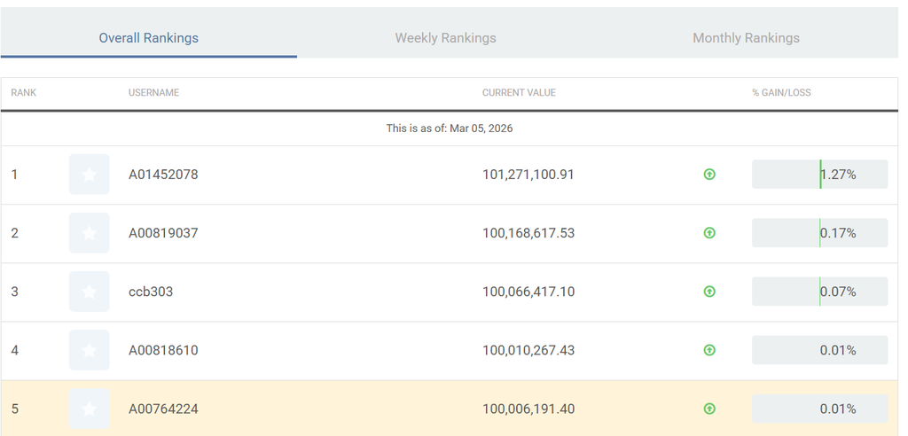

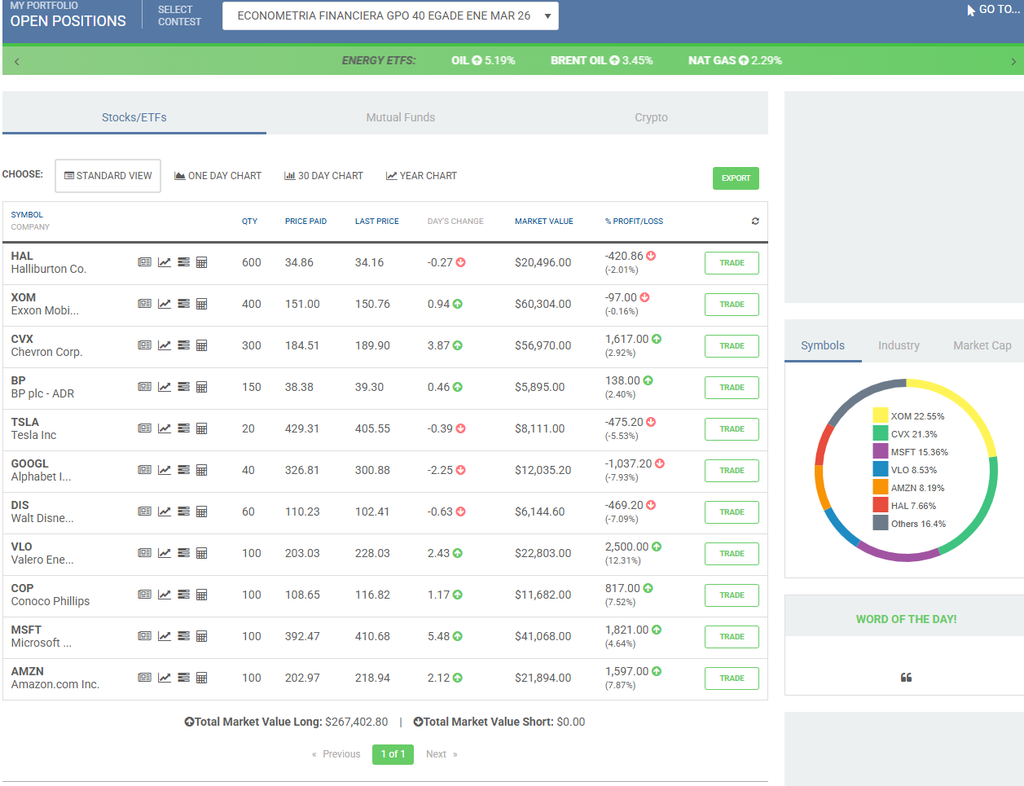

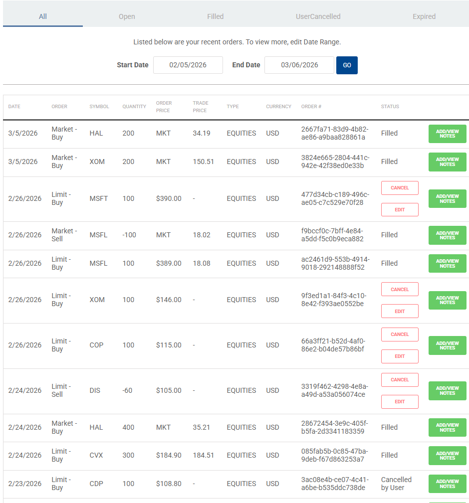